# Project 2: Group 4

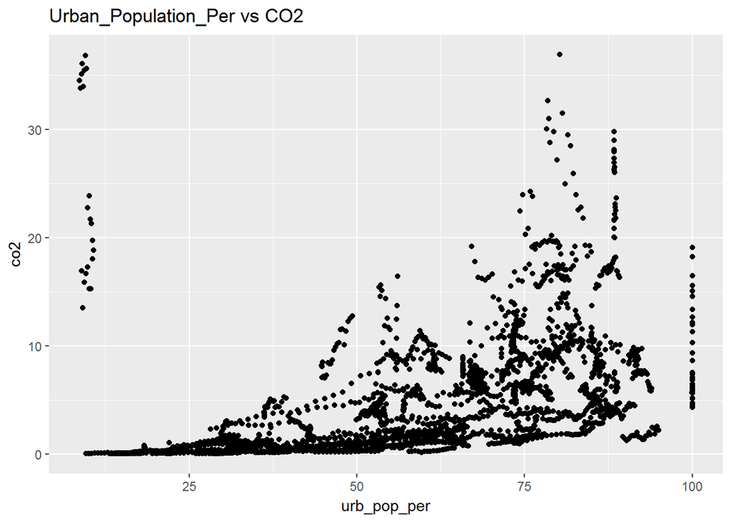

```r
ggplot(newtotal, aes(x=urb_pop_per, y=co2)) + geom_point() + ggtitle("Urban_Population_Per vs CO2")
```

We also check boxplots to see for outliers in our data which could prove problematic.

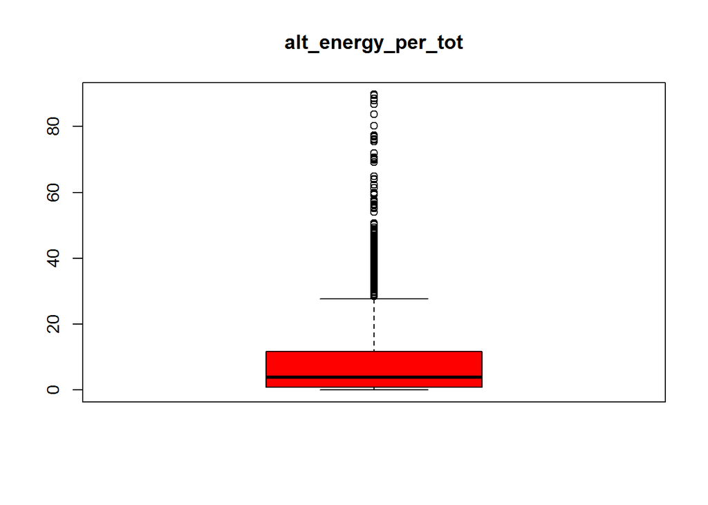

```r
boxplot(newtotal$alt_energy_per_tot, data = newtotal, main = "alt_energy_per_tot", col = "red")
```

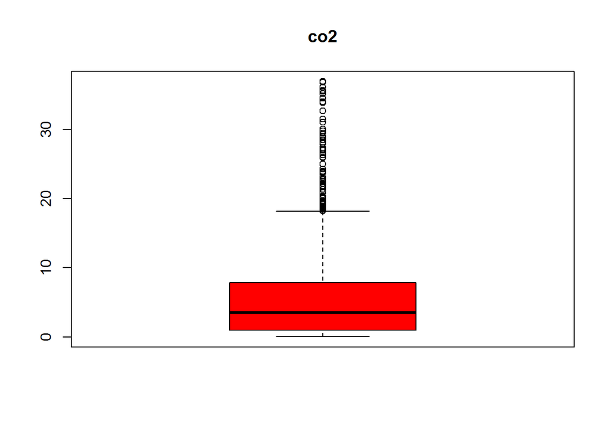

```r
boxplot(newtotal$co2, data = newtotal, main = "co2", col = "red")
```

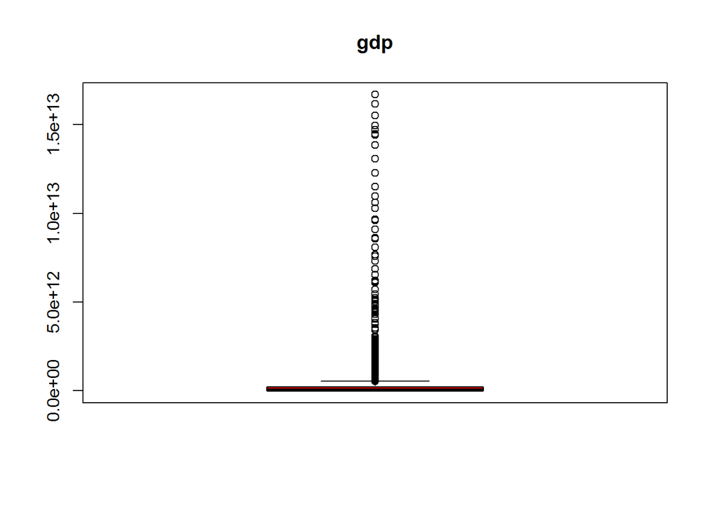

```r
boxplot(newtotal$gdp, data = newtotal, main = "gdp", col = "red")
```

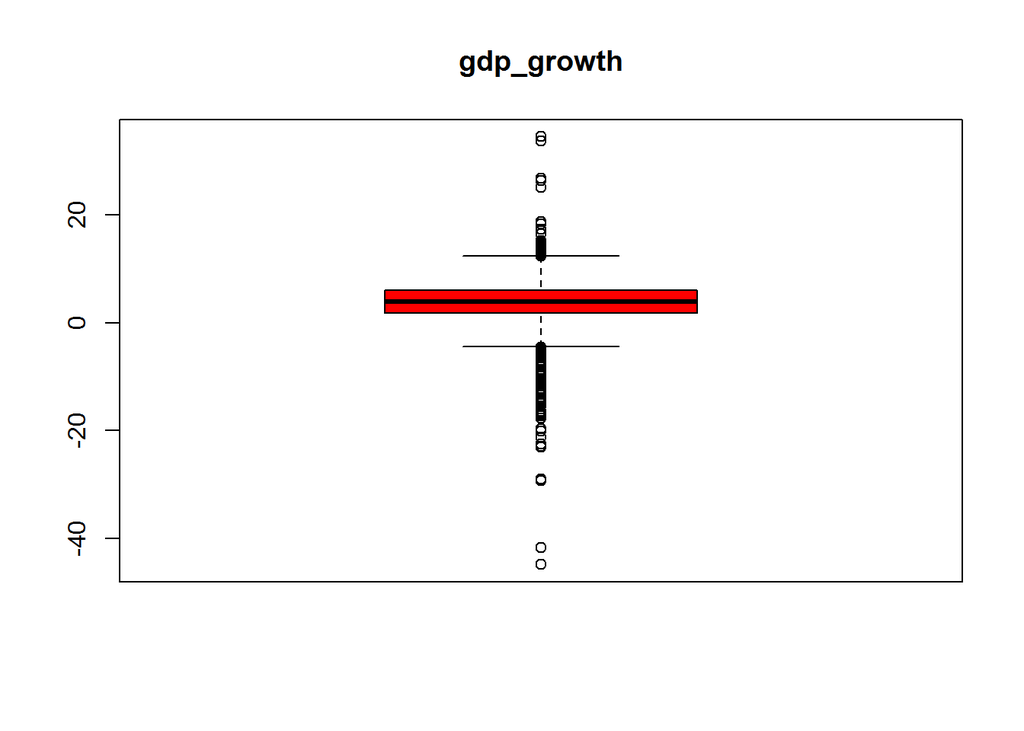

```r
boxplot(newtotal$gdp_growth, data = newtotal, main = "gdp_growth", col = "red")
```

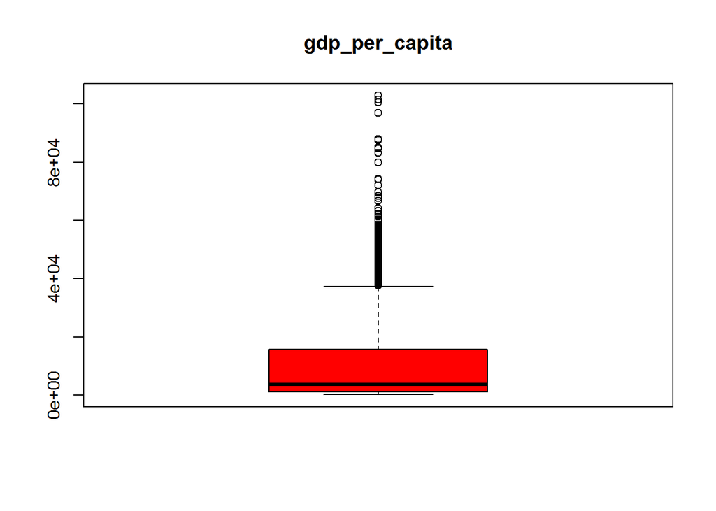

```r
boxplot(newtotal$gdp_per_capita, data = newtotal, main = "gdp_per_capita", col = "red")
```

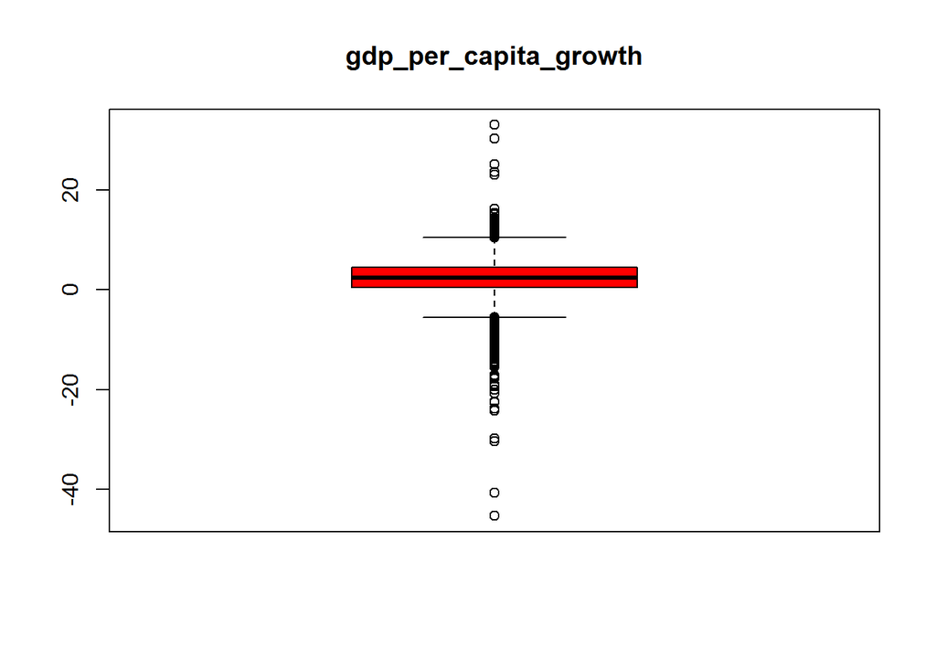

```r
boxplot(newtotal$gdp_per_capita_growth, data = newtotal, main = "gdp_per_capita_growth", col = "red")
```

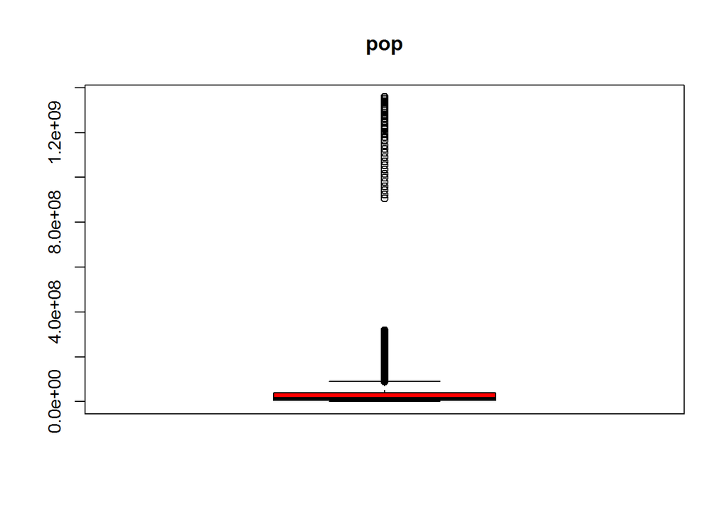

```r
boxplot(newtotal$pop, data = newtotal, main = "pop", col = "red")
```

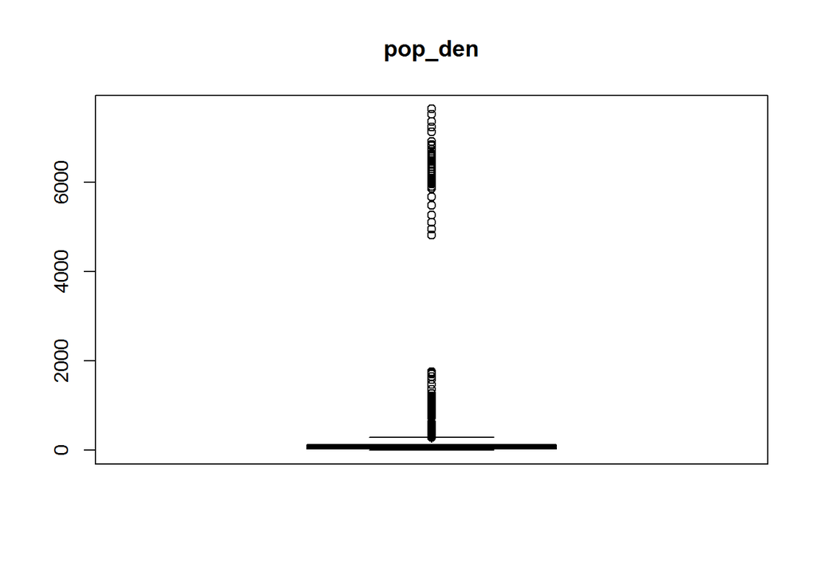

```r
boxplot(newtotal$pop_den, data = newtotal, main = "pop_den", col = "red")
```

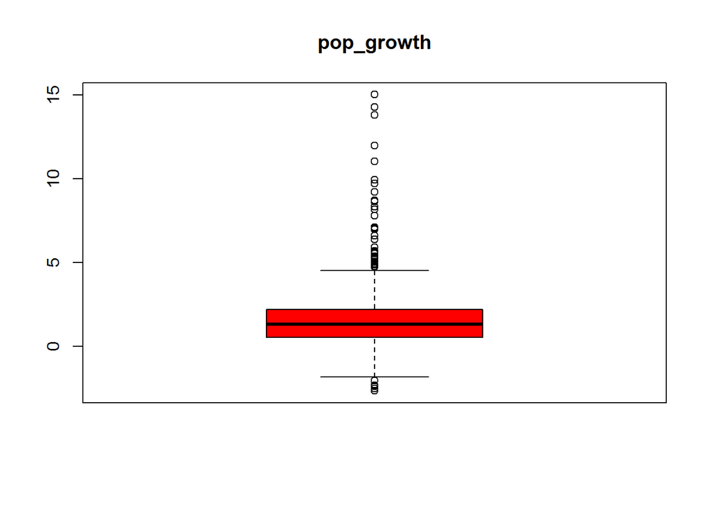

```r
boxplot(newtotal$pop_growth, data = newtotal, main = "pop_growth", col = "red")
```

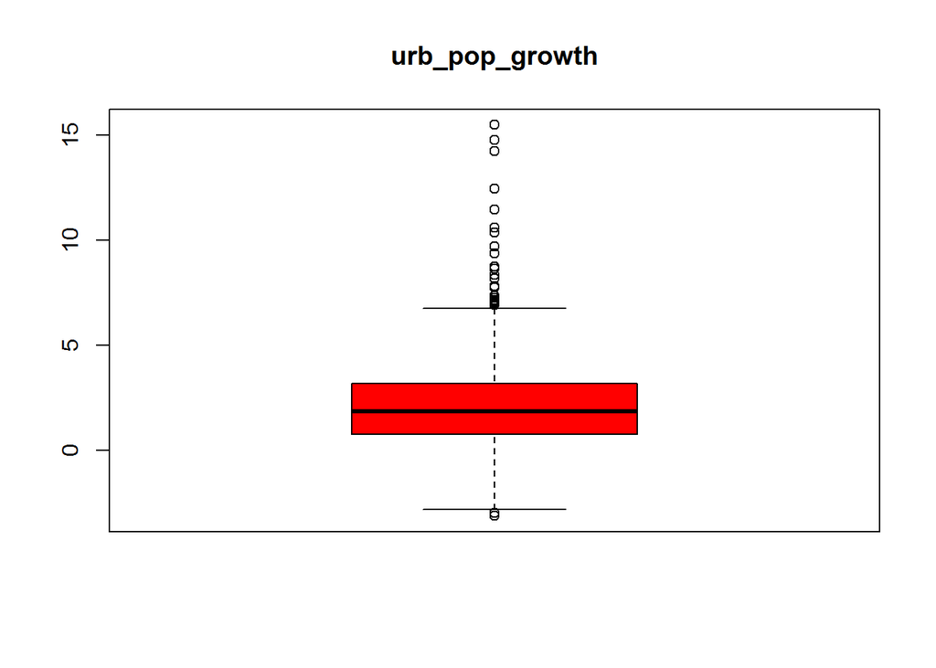

```r
boxplot(newtotal$urb_pop_growth, data = newtotal, main = "urb_pop_growth", col = "red")
```

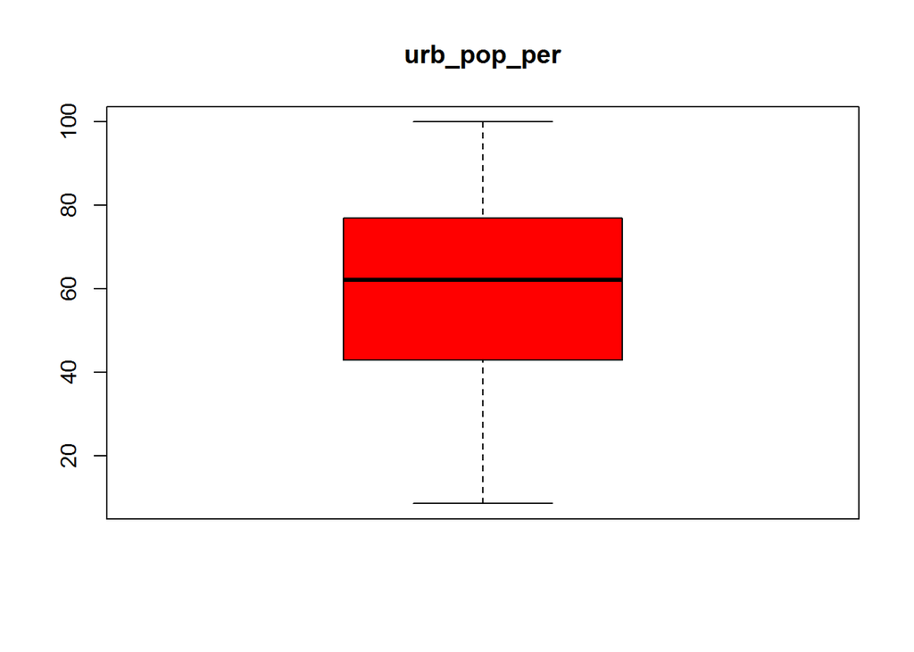

```r
boxplot(newtotal$urb_pop_per, data = newtotal, main = "urb_pop_per", col = "red")
```

We notice that we don’t have the most normal data as well as a lot of outliers which may prove to be a problem. However, with using multiple regression we may still be able to successfully predict the CO2 output.

We continue on with scaling all of the data for our analysis.

```r
newtotalScaled <- newtotal
newtotalScaled$alt_energy_per_tot <- scale(newtotal$alt_energy_per_tot)
newtotalScaled$gdp <- scale(newtotal$gdp)
newtotalScaled$gdp_growth <- scale(newtotal$gdp_growth)
newtotalScaled$gdp_per_capita <- scale(newtotal$gdp_per_capita)
newtotalScaled$gdp_per_capita_growth <- scale(newtotal$gdp_per_capita_growth)
newtotalScaled$pop <- scale(newtotal$pop)
newtotalScaled$pop_den <- scale(newtotal$pop_den)
newtotalScaled$pop_growth <- scale(newtotal$pop_growth)
newtotalScaled$urb_pop_growth <- scale(newtotal$urb_pop_growth)
newtotalScaled$urb_pop_per <- scale(newtotal$urb_pop_per)
summary(newtotalScaled)
```

```
##       year         country     alt_energy_per_tot.V1      co2
##  Min.   :1992   ALB    :  22   Min.   :-0.678878     Min.   : 0.04047
##  1st Qu.:1997   ARE    :  22   1st Qu.:-0.622197     1st Qu.: 0.99955
##  Median :2002   ARG    :  22   Median :-0.395758     Median : 3.54335
##  Mean   :2002   ARM    :  22   Mean   : 0.000000     Mean   : 5.28354
##  3rd Qu.:2008   AUS    :  22   3rd Qu.: 0.192088     3rd Qu.: 7.87566
##  Max.   :2013   AUT    :  22   Max.   : 5.999634     Max.   :36.90410
##                 (Other):2222
##        gdp.V1           gdp_growth.V1      gdp_per_capita.V1
##  Min.   :-0.297868   Min.   :-10.065374   Min.   :-0.714499
##  1st Qu.:-0.290246   1st Qu.: -0.376845   1st Qu.:-0.653447
##  Median :-0.262894   Median :  0.060514   Median :-0.480560
##  Mean   : 0.000000   Mean   :  0.000000   Mean   : 0.000000
##  3rd Qu.:-0.129857   3rd Qu.:  0.498299   3rd Qu.: 0.302350
##  Max.   :12.050445   Max.   :  6.406197   Max.   : 6.020621
##
##  gdp_per_capita_growth.V1       pop.V1            pop_den.V1
##  Min.   :-9.932364        Min.   :-0.323930   Min.   :-0.275123
##  1st Qu.:-0.353251        1st Qu.:-0.295354   1st Qu.:-0.245518
##  Median : 0.037071        Median :-0.251008   Median :-0.193357
##  Mean   : 0.000000        Mean   : 0.000000   Mean   : 0.000000
##  3rd Qu.: 0.482463        3rd Qu.:-0.090403   3rd Qu.:-0.123139
##  Max.   : 6.454389        Max.   : 7.930015   Max.   : 8.612236
##
##     pop_growth.V1     urb_pop_growth.V1     urb_pop_per.V1
##  Min.   :-2.997390   Min.   :-2.946777   Min.   :-2.3887938
##  1st Qu.:-0.666255   1st Qu.:-0.732431   1st Qu.:-0.7880614
##  Median :-0.079782   Median :-0.108516   Median : 0.1061734
##  Mean   : 0.000000   Mean   : 0.000000   Mean   : 0.0000000
##  3rd Qu.: 0.558391   3rd Qu.: 0.641772   3rd Qu.: 0.7935422
##  Max.   : 9.995992   Max.   : 7.670274   Max.   : 1.8646750
##
```

```r
head(newtotalScaled)
```

```
##    year country alt_energy_per_tot        co2         gdp  gdp_growth
## 4  1992     ALB          0.8415510  0.7747249 -0.29786814 -2.24448951
## 6  1992     ARE         -0.6788782 28.7945591 -0.25826535 -0.05693535
## 7  1992     ARG         -0.1554426  3.6085822 -0.12912851  1.72627391
## 8  1992     ARM         -0.2071464  1.5998956 -0.29745152 -9.42227761
## 11 1992     AUS         -0.5587524 15.3177685 -0.05776175 -0.66807165
## 12 1992     AUT          0.2073218  7.2262364 -0.15441657 -0.31654310
##    gdp_per_capita gdp_per_capita_growth        pop    pop_den  pop_growth
## 4      -0.7074909            -1.8410881 -0.3057691 -0.1388661 -1.48944732
## 6       1.0382666            -0.8866520 -0.3132379 -0.2486930  2.90977838
## 7      -0.2764167             1.7229997 -0.1208282 -0.2624899 -0.03064161
## 8      -0.6976355            -8.9749161 -0.3045378 -0.1357728 -2.36103220
## 11      0.4962430            -0.6231689 -0.2191136 -0.2741536 -0.15295194
## 12      0.9043516            -0.2492479 -0.2778306 -0.1662875 -0.23582149
##    urb_pop_growth urb_pop_per
## 4      -0.6722936  -1.0576696
## 6       1.7958727   0.8755179
## 7      -0.2459343   1.2844999
## 8      -2.4305698   0.3221673
## 11     -0.3699734   1.1924766
## 12     -0.5453807   0.2719644
```

Then, as mentioned above, we remove gdp_growth, urban population growth, and urban population percentage of the whole population due to a strong correlation with another. This fixes our multicollinearity problem.

```r
newtotalScaled <- newtotalScaled[,c(-6,-12,-13)]
head(newtotalScaled)
```

```
##    year country alt_energy_per_tot        co2         gdp gdp_per_capita
## 4  1992     ALB          0.8415510  0.7747249 -0.29786814     -0.7074909
## 6  1992     ARE         -0.6788782 28.7945591 -0.25826535      1.0382666
## 7  1992     ARG         -0.1554426  3.6085822 -0.12912851     -0.2764167
## 8  1992     ARM         -0.2071464  1.5998956 -0.29745152     -0.6976355
## 11 1992     AUS         -0.5587524 15.3177685 -0.05776175      0.4962430
## 12 1992     AUT          0.2073218  7.2262364 -0.15441657      0.9043516
##    gdp_per_capita_growth        pop    pop_den  pop_growth
## 4             -1.8410881 -0.3057691 -0.1388661 -1.48944732
## 6             -0.8866520 -0.3132379 -0.2486930  2.90977838
## 7              1.7229997 -0.1208282 -0.2624899 -0.03064161
## 8             -8.9749161 -0.3045378 -0.1357728 -2.36103220
## 11            -0.6231689 -0.2191136 -0.2741536 -0.15295194
## 12            -0.2492479 -0.2778306 -0.1662875 -0.23582149
```

```r
newtotalglm <- newtotalScaled[c(3,5:10,4)]
bglm <- bestglm(Xy=newtotalglm, IC="AIC",method = "forward")
bglm$BestModels
```

```
##   alt_energy_per_tot  gdp gdp_per_capita gdp_per_capita_growth  pop
## 1               TRUE TRUE           TRUE                 FALSE TRUE
## 2               TRUE TRUE           TRUE                 FALSE TRUE
## 3               TRUE TRUE           TRUE                  TRUE TRUE
## 4               TRUE TRUE           TRUE                  TRUE TRUE
## 5               TRUE TRUE           TRUE                 FALSE TRUE
##   pop_den pop_growth Criterion
## 1    TRUE       TRUE  7100.436
## 2   FALSE       TRUE  7102.263
## 3    TRUE       TRUE  7102.434
## 4   FALSE       TRUE  7104.234
## 5    TRUE      FALSE  7106.110
```

```r
bglm <- bestglm(Xy=newtotalglm, IC="AIC",method = "backward")
bglm$BestModels
```

```
##   alt_energy_per_tot  gdp gdp_per_capita gdp_per_capita_growth  pop
## 1               TRUE TRUE           TRUE                 FALSE TRUE
## 2               TRUE TRUE           TRUE                 FALSE TRUE
## 3               TRUE TRUE           TRUE                  TRUE TRUE
## 4               TRUE TRUE           TRUE                 FALSE TRUE
## 5               TRUE TRUE           TRUE                 FALSE TRUE
##   pop_den pop_growth Criterion
## 1    TRUE       TRUE  7100.436
## 2   FALSE       TRUE  7102.263
## 3    TRUE       TRUE  7102.434
## 4    TRUE      FALSE  7106.110
## 5   FALSE      FALSE  7107.854
```

```r
bglm <- bestglm(Xy=newtotalglm, IC="BIC",method = "forward")
bglm$BestModels
```

```
##   alt_energy_per_tot  gdp gdp_per_capita gdp_per_capita_growth   pop
## 1               TRUE TRUE           TRUE                 FALSE  TRUE
## 2               TRUE TRUE           TRUE                 FALSE  TRUE
## 3               TRUE TRUE           TRUE                 FALSE  TRUE
## 4               TRUE TRUE           TRUE                 FALSE  TRUE
## 5               TRUE TRUE           TRUE                 FALSE FALSE
##   pop_den pop_growth Criterion
## 1   FALSE      FALSE  7130.909
## 2   FALSE       TRUE  7131.083
## 3    TRUE      FALSE  7134.930
## 4    TRUE       TRUE  7135.020
## 5   FALSE       TRUE  7136.281
```

```r
bglm <- bestglm(Xy=newtotalglm, IC="BIC",method = "backward")
bglm$BestModels
```

```
##   alt_energy_per_tot  gdp gdp_per_capita gdp_per_capita_growth   pop
## 1               TRUE TRUE           TRUE                 FALSE  TRUE
## 2               TRUE TRUE           TRUE                 FALSE  TRUE
## 3               TRUE TRUE           TRUE                 FALSE  TRUE
## 4               TRUE TRUE           TRUE                 FALSE  TRUE
## 5               TRUE TRUE           TRUE                 FALSE FALSE
##   pop_den pop_growth Criterion
## 1   FALSE      FALSE  7130.909
## 2   FALSE       TRUE  7131.083
## 3    TRUE      FALSE  7134.930
## 4    TRUE       TRUE  7135.020
## 5   FALSE      FALSE  7136.513
```

Also checking our model selection we use regsubsets using the Adjusted R squared, Cp, and BIC.

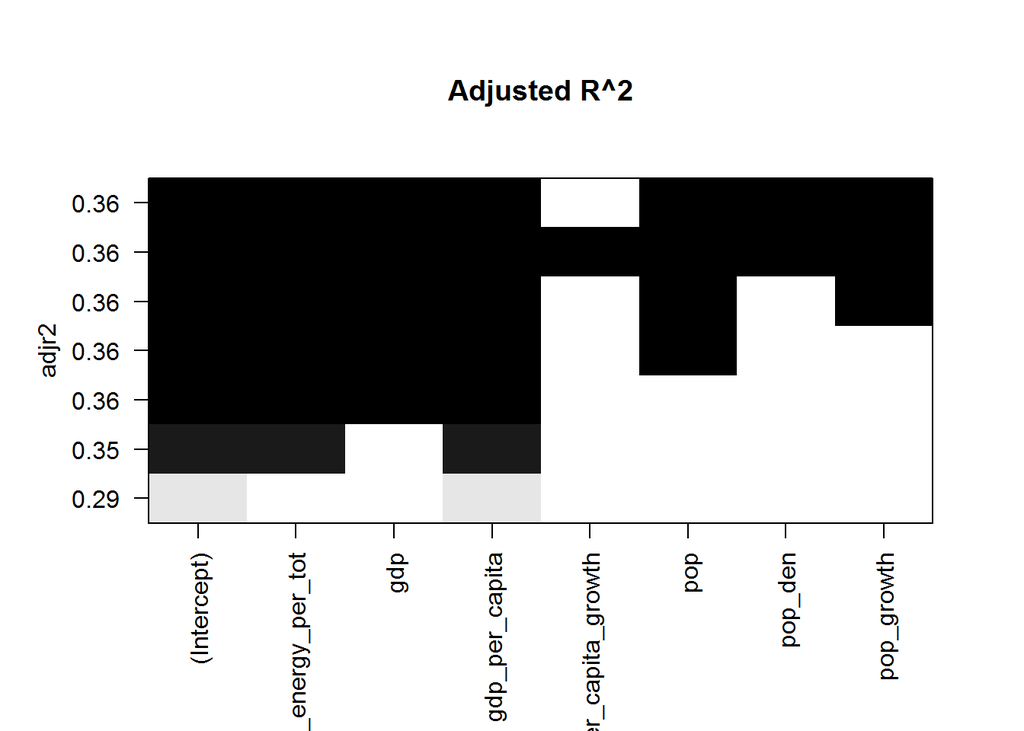

```r
#This is essentially best fit
reg.best <- regsubsets(co2~. -year - country, data =newtotalScaled)
plot(reg.best, scale = "adjr2", main = "Adjusted R^2")
```

```r
summary(reg.best)
```

```
## Subset selection object
## Call: regsubsets.formula(co2 ~ . - year - country, data = newtotalScaled)
## 7 Variables  (and intercept)
##                       Forced in Forced out
## alt_energy_per_tot        FALSE      FALSE
## gdp                       FALSE      FALSE
## gdp_per_capita            FALSE      FALSE
## gdp_per_capita_growth     FALSE      FALSE
## pop                       FALSE      FALSE
## pop_den                   FALSE      FALSE
## pop_growth                FALSE      FALSE
## 1 subsets of each size up to 7
## Selection Algorithm: exhaustive
##          alt_energy_per_tot gdp gdp_per_capita gdp_per_capita_growth pop
## 1  ( 1 ) " "                " " "*"            " "                   " "
## 2  ( 1 ) "*"                " " "*"            " "                   " "
## 3  ( 1 ) "*"                "*" "*"            " "                   " "
## 4  ( 1 ) "*"                "*" "*"            " "                   "*"
## 5  ( 1 ) "*"                "*" "*"            " "                   "*"
## 6  ( 1 ) "*"                "*" "*"            " "                   "*"
## 7  ( 1 ) "*"                "*" "*"            "*"                   "*"
##          pop_den pop_growth
## 1  ( 1 ) " "     " "
## 2  ( 1 ) " "     " "
## 3  ( 1 ) " "     " "
## 4  ( 1 ) " "     " "
## 5  ( 1 ) " "     "*"
## 6  ( 1 ) "*"     "*"
## 7  ( 1 ) "*"     "*"
```

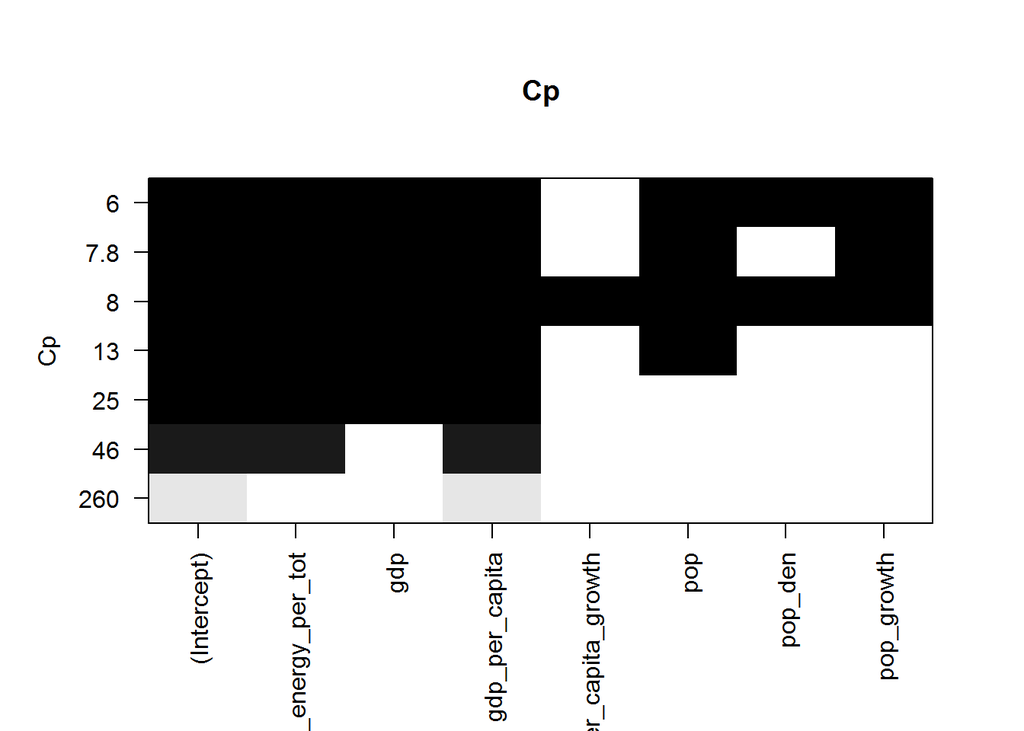

```r
plot(reg.best, scale = "Cp", main = "Cp")
```

```r
summary(reg.best)
```

```
## Subset selection object
## Call: regsubsets.formula(co2 ~ . - year - country, data = newtotalScaled)
## 7 Variables  (and intercept)
##                       Forced in Forced out
## alt_energy_per_tot        FALSE      FALSE
## gdp                       FALSE      FALSE
## gdp_per_capita            FALSE      FALSE
## gdp_per_capita_growth     FALSE      FALSE
## pop                       FALSE      FALSE
## pop_den                   FALSE      FALSE
## pop_growth                FALSE      FALSE
## 1 subsets of each size up to 7
## Selection Algorithm: exhaustive
##          alt_energy_per_tot gdp gdp_per_capita gdp_per_capita_growth pop
## 1  ( 1 ) " "                " " "*"            " "                   " "
## 2  ( 1 ) "*"                " " "*"            " "                   " "
## 3  ( 1 ) "*"                "*" "*"            " "                   " "
## 4  ( 1 ) "*"                "*" "*"            " "                   "*"
## 5  ( 1 ) "*"                "*" "*"            " "                   "*"
## 6  ( 1 ) "*"                "*" "*"            " "                   "*"
## 7  ( 1 ) "*"                "*" "*"            "*"                   "*"
##          pop_den pop_growth
## 1  ( 1 ) " "     " "
## 2  ( 1 ) " "     " "
## 3  ( 1 ) " "     " "
## 4  ( 1 ) " "     " "
## 5  ( 1 ) " "     "*"
## 6  ( 1 ) "*"     "*"
## 7  ( 1 ) "*"     "*"
```

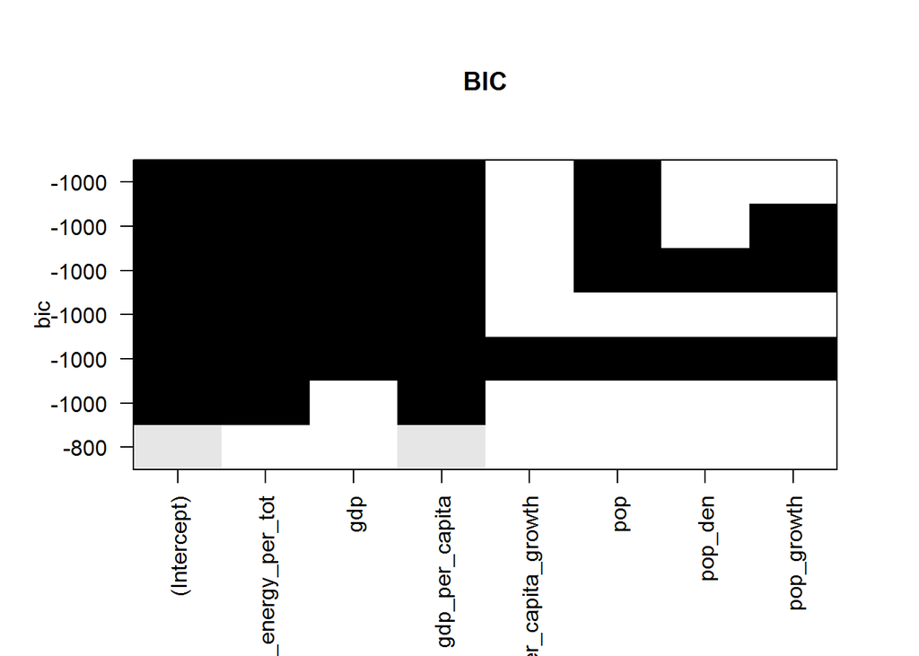

```r
plot(reg.best, scale = "bic", main = "BIC")
```

```r
summary(reg.best)
```

```
## Subset selection object
## Call: regsubsets.formula(co2 ~ . - year - country, data = newtotalScaled)
## 7 Variables  (and intercept)
##                       Forced in Forced out
## alt_energy_per_tot        FALSE      FALSE
## gdp                       FALSE      FALSE
## gdp_per_capita            FALSE      FALSE
## gdp_per_capita_growth     FALSE      FALSE
## pop                       FALSE      FALSE
## pop_den                   FALSE      FALSE
## pop_growth                FALSE      FALSE
## 1 subsets of each size up to 7
## Selection Algorithm: exhaustive
##          alt_energy_per_tot gdp gdp_per_capita gdp_per_capita_growth pop
## 1  ( 1 ) " "                " " "*"            " "                   " "
## 2  ( 1 ) "*"                " " "*"            " "                   " "
## 3  ( 1 ) "*"                "*" "*"            " "                   " "
## 4  ( 1 ) "*"                "*" "*"            " "                   "*"
## 5  ( 1 ) "*"                "*" "*"            " "                   "*"
## 6  ( 1 ) "*"                "*" "*"            " "                   "*"
## 7  ( 1 ) "*"                "*" "*"            "*"                   "*"
##          pop_den pop_growth
## 1  ( 1 ) " "     " "
## 2  ( 1 ) " "     " "
## 3  ( 1 ) " "     " "
## 4  ( 1 ) " "     " "
## 5  ( 1 ) " "     "*"
## 6  ( 1 ) "*"     "*"
## 7  ( 1 ) "*"     "*"
```

We see that we end up with two different models to check. We will then take the best one from these options. This leads us to our training and testing data sets. We seperate them here. Our models are separated by 75% for training to 25% for testing.

```r
#Have to create training data
newtotal_train <- newtotalScaled[1:1782, ]
newtotal_co2 <- newtotalScaled[1783:2354, 4]
test_co2 <- newtotalScaled[1783:2354, -4]

head(newtotal_train)
```

```
##    year country alt_energy_per_tot        co2         gdp gdp_per_capita
## 4  1992     ALB          0.8415510  0.7747249 -0.29786814     -0.7074909
## 6  1992     ARE         -0.6788782 28.7945591 -0.25826535      1.0382666
## 7  1992     ARG         -0.1554426  3.6085822 -0.12912851     -0.2764167
## 8  1992     ARM         -0.2071464  1.5998956 -0.29745152     -0.6976355
## 11 1992     AUS         -0.5587524 15.3177685 -0.05776175      0.4962430
## 12 1992     AUT          0.2073218  7.2262364 -0.15441657      0.9043516
##    gdp_per_capita_growth        pop    pop_den  pop_growth
## 4             -1.8410881 -0.3057691 -0.1388661 -1.48944732
## 6             -0.8866520 -0.3132379 -0.2486930  2.90977838
## 7              1.7229997 -0.1208282 -0.2624899 -0.03064161
## 8             -8.9749161 -0.3045378 -0.1357728 -2.36103220
## 11            -0.6231689 -0.2191136 -0.2741536 -0.15295194
## 12            -0.2492479 -0.2778306 -0.1662875 -0.23582149
```

```r
head(newtotal_co2)
```

```
## [1] 10.5414923 11.6795833  0.1299634  8.0290410 16.1015677  0.9753141
```

```r
head(test_co2)
```

```
##      year country alt_energy_per_tot         gdp gdp_per_capita
## 3583 2008     NLD         -0.5384920  0.39425464      3.0080241
## 3584 2008     NOR          2.1024180  0.04336829      5.6255562
## 3585 2008     NPL         -0.4926314 -0.28911154     -0.6905832
## 3587 2008     NZL          1.2975976 -0.19978948      1.3280781
## 3588 2008     OMN         -0.6788782 -0.25333354      0.7826956
## 3589 2008     PAK         -0.4241075 -0.17256455     -0.6534843
##      gdp_per_capita_growth        pop     pop_den pop_growth
## 3583            -0.1806875 -0.2254960  0.29021126 -0.7581768
## 3584            -0.6330375 -0.2965174 -0.26160870 -0.1287589
## 3585             0.6028240 -0.1654087 -0.06304672 -0.3107273
## 3587            -0.9016257 -0.2996095 -0.25797350 -0.4207829
## 3588             0.7620852 -0.3093864 -0.26682949  0.5947796
## 3589            -0.5317296  0.6664320 -0.03053687  0.4705907
```

Since we are using data looking at the same countries over multiple time periods, we have panel data and need to create a model based on panel data. That is where PLM comes into play. PLM is a panel data estimator that applies a linear model on transformed data. We use it to create our two models.

```r
model1 <- plm(co2~alt_energy_per_tot+gdp+gdp_per_capita+pop+pop_den+pop_growth, data = newtotal_train, index=c("country", "year"), model ="random", effect="time")
model2 <- plm(co2~alt_energy_per_tot+gdp+gdp_per_capita+pop, data = newtotal_train, index=c("country", "year"), model="random", effect="time")
```

We get the summary of the data.

```r
summary(model1)
```

```
## Oneway (time) effect Random Effect Model
##    (Swamy-Arora's transformation)
##
## Call:
## plm(formula = co2 ~ alt_energy_per_tot + gdp + gdp_per_capita +
##     pop + pop_den + pop_growth, data = newtotal_train, effect = "time",
##     model = "random", index = c("country", "year"))
##
## Unbalanced Panel: n=107, T=16-17, N=1782
##
## Effects:
```

```
##                   var std.dev  share
## idiosyncratic 18.2576  4.2729  1.009
## time          -0.1669      NA -0.009
## theta  :
##    Min. 1st Qu.  Median    Mean 3rd Qu.    Max.
## -5.7410 -5.7410 -5.7410 -5.5410 -5.7410 -0.6662
##
## Residuals :
##    Min. 1st Qu.  Median    Mean 3rd Qu.    Max.
## -9.5200 -3.2800 -1.2400 -0.0468  1.9800 28.1000
##
## Coefficients :
##                     Estimate Std. Error  t-value  Pr(>|t|)
## (Intercept)         5.487229   0.020421 268.6991 < 2.2e-16 ***
## alt_energy_per_tot -0.995026   0.126731  -7.8515 7.057e-15 ***
## gdp                 0.847504   0.157647   5.3760 8.627e-08 ***
## gdp_per_capita      2.029348   0.113631  17.8591 < 2.2e-16 ***
## pop                -0.607680   0.122066  -4.9783 7.036e-07 ***
## pop_den             0.088256   0.123017   0.7174  0.473203
## pop_growth          0.296380   0.101606   2.9170  0.003579 **
## ---
## Signif. codes:  0 '***' 0.001 '**' 0.01 '*' 0.05 '.' 0.1 ' ' 1
##
## Total Sum of Squares:    102910
## Residual Sum of Squares: 40875
## R-Squared:      0.60425
## Adj. R-Squared: 0.60292
## F-statistic: 448.994 on 6 and 1775 DF, p-value: < 2.22e-16
```

```r
summary(model2)
```

```
## Oneway (time) effect Random Effect Model
##    (Swamy-Arora's transformation)
##
## Call:
## plm(formula = co2 ~ alt_energy_per_tot + gdp + gdp_per_capita +
##     pop, data = newtotal_train, effect = "time", model = "random",
##     index = c("country", "year"))
##
## Unbalanced Panel: n=107, T=16-17, N=1782
##
## Effects:
```

```
##                   var std.dev  share
## idiosyncratic 18.3124  4.2793  1.009
## time          -0.1667      NA -0.009
## theta  :
##    Min. 1st Qu.  Median    Mean 3rd Qu.    Max.
## -5.1950 -5.1950 -5.1950 -5.0170 -5.1950 -0.6601
##
## Residuals :
##    Min. 1st Qu.  Median    Mean 3rd Qu.    Max.
## -8.6400 -3.1500 -1.2400 -0.0477  1.8100 28.4000
##
## Coefficients :
##                    Estimate Std. Error  t-value  Pr(>|t|)
## (Intercept)         5.50120    0.02182 252.1135 < 2.2e-16 ***
## alt_energy_per_tot -1.13747    0.11979  -9.4955 < 2.2e-16 ***
## gdp                 0.77668    0.15513   5.0067 6.086e-07 ***
## gdp_per_capita      2.19417    0.11337  19.3534 < 2.2e-16 ***
## pop                -0.60383    0.12135  -4.9760 7.120e-07 ***
## ---
## Signif. codes:  0 '***' 0.001 '**' 0.01 '*' 0.05 '.' 0.1 ' ' 1
##
## Total Sum of Squares:    93322
## Residual Sum of Squares: 40479
## R-Squared:      0.5679
## Adj. R-Squared: 0.56692
## F-statistic: 579.951 on 4 and 1777 DF, p-value: < 2.22e-16
```

We then need to test our models. Therefore, we apply our models on our test data.

```r
predict.model1 <- predict(model1,test_co2)
predict.model2 <- predict(model2,test_co2)

model1.diff <- predict.model1 - newtotal_co2
model2.diff <- predict.model2 - newtotal_co2
```

And we compare them to the actual values.

```r
compare <- data.frame(predict.model1, model1.diff, predict.model2, model2.diff, newtotal_co2)
head(compare)
```

```
##   predict.model1 model1.diff predict.model2 model2.diff newtotal_co2
## 1      12.399435    1.857943      13.156208    2.614716   10.5414923
## 2      14.967170    3.287587      15.665922    3.986338   11.6795833
## 3       4.333811    4.203848       4.421630    4.291667    0.1299634
## 4       6.756483   -1.272558       6.964995   -1.064046    8.0290410
## 5       7.877131   -8.224437       7.980831   -8.120736   16.1015677
## 6       4.168632    3.193318       4.013313    3.037999    0.9753141
```

To see how good our fit performed we calculate the root mean square.

```r
MSE1 <- mean((compare$predict.model1-compare$newtotal_co2)^2)
RMSE1 <- sqrt(MSE1)
RMSE1
```

```
## [1] 4.879719
```

```r
MSE2 <- mean((compare$predict.model2-compare$newtotal_co2)^2)
RMSE2 <- sqrt(MSE2)
RMSE2
```

```
## [1] 4.876926
```

Our RMSE is pretty high for our data, so we wondered if we could get it lower by adding one more variable. Therefore we seperated our countries into two groups, G20 and the Rest of the World (ROW). We chose these based on G20 countries are deemed as developed or developing and their factors may be more related to one another while the rest of the world may be related more to each other.

```r
newtotalScaled$group <- ifelse(newtotalScaled$country == "ARG" ,"G20", ifelse(newtotalScaled$country == "FRA" ,"G20", ifelse(newtotalScaled$country == "DEU","G20", ifelse(newtotalScaled$country == "IND" ,"G20", ifelse(newtotalScaled$country == "IDN" ,"G20", ifelse(newtotalScaled$country == "ITA" ,"G20", ifelse(newtotalScaled$country == "JPN" ,"G20", ifelse(newtotalScaled$country == "KOR" ,"G20", ifelse(newtotalScaled$country == "MEX" ,"G20", ifelse(newtotalScaled$country == "RUS","G20", ifelse(newtotalScaled$country == "SAU","G20", ifelse(newtotalScaled$country == "ZAF", "G20", ifelse(newtotalScaled$country == "TUR","G20", ifelse(newtotalScaled$country == "GBR" ,"G20", ifelse(newtotalScaled$country == "AUS", "G20", ifelse(newtotalScaled$country == "BRA", "G20", ifelse(newtotalScaled$country == "CAN", "G20", ifelse(newtotalScaled$country == "CHN", "G20", "ROW"))))))))))))))))))

newtotal$group <- ifelse(newtotal$country == "ARG" ,"G20", ifelse(newtotal$country == "FRA" ,"G20", ifelse(newtotal$country == "DEU","G20", ifelse(newtotal$country == "IND" ,"G20", ifelse(newtotal$country == "IDN" ,"G20", ifelse(newtotal$country == "ITA" ,"G20", ifelse(newtotal$country == "JPN" ,"G20", ifelse(newtotal$country == "KOR" ,"G20", ifelse(newtotal$country == "MEX" ,"G20", ifelse(newtotal$country == "RUS","G20", ifelse(newtotal$country == "SAU","G20", ifelse(newtotal$country == "ZAF", "G20", ifelse(newtotal$country == "TUR","G20", ifelse(newtotal$country == "GBR" ,"G20", ifelse(newtotal$country == "AUS", "G20", ifelse(newtotal$country == "BRA", "G20", ifelse(newtotal$country == "CAN", "G20", ifelse(newtotal$country == "CHN", "G20", "ROW"))))))))))))))))))

row <- split(newtotalScaled, newtotalScaled$group)[["ROW"]] #All the BRICS data
g20 <- split(newtotalScaled, newtotalScaled$group)[["G20"]] #All G7 data
newtotalScaled$group <- as.factor(newtotalScaled$group)
head(newtotalScaled)
```

```
##    year country alt_energy_per_tot        co2         gdp gdp_per_capita
## 4  1992     ALB          0.8415510  0.7747249 -0.29786814     -0.7074909
## 6  1992     ARE         -0.6788782 28.7945591 -0.25826535      1.0382666
## 7  1992     ARG         -0.1554426  3.6085822 -0.12912851     -0.2764167
## 8  1992     ARM         -0.2071464  1.5998956 -0.29745152     -0.6976355
## 11 1992     AUS         -0.5587524 15.3177685 -0.05776175      0.4962430
## 12 1992     AUT          0.2073218  7.2262364 -0.15441657      0.9043516
##    gdp_per_capita_growth        pop    pop_den  pop_growth group
## 4             -1.8410881 -0.3057691 -0.1388661 -1.48944732   ROW
## 6             -0.8866520 -0.3132379 -0.2486930  2.90977838   ROW
## 7              1.7229997 -0.1208282 -0.2624899 -0.03064161   G20
## 8             -8.9749161 -0.3045378 -0.1357728 -2.36103220   ROW
## 11            -0.6231689 -0.2191136 -0.2741536 -0.15295194   G20
## 12            -0.2492479 -0.2778306 -0.1662875 -0.23582149   ROW
```

We once again run regsubsets on the data to see what variables our model should include.

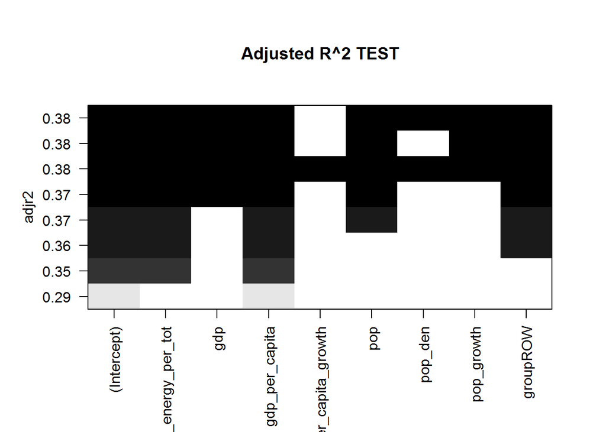

```r
#This is essentially best fit
reg.besttest <- regsubsets(co2~.-year-country, data=newtotalScaled)
plot(reg.besttest, scale="adjr2", main="Adjusted R^2 TEST")
```

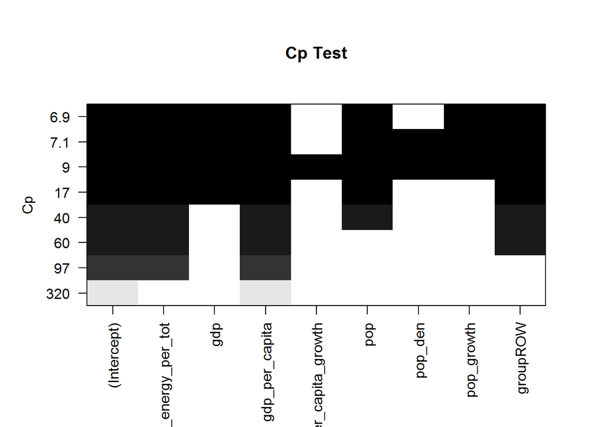

```r
plot(reg.besttest, scale="Cp", main="Cp Test")
```

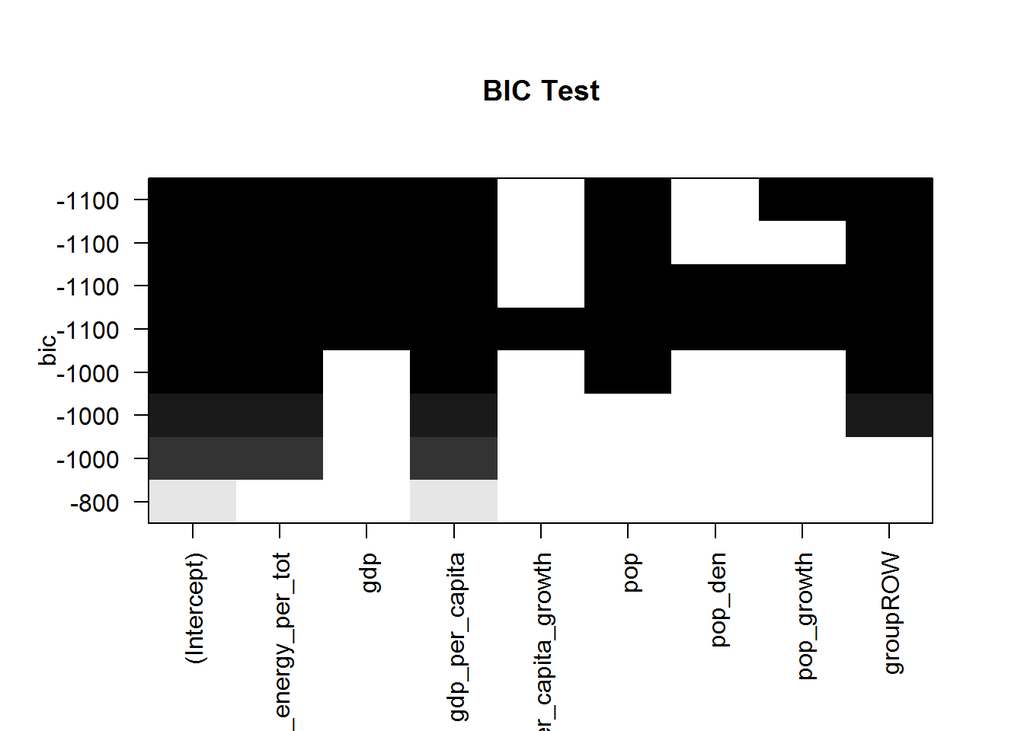

```r
plot(reg.besttest, scale="bic", main="BIC Test")
```

We split the data once again into training and testing sets.

```r
#Have to create training data
newtotal_trainT <- newtotalScaled[1:1782, ]
newtotal_co2T <- newtotalScaled[1782:2354, 4]
test_co2T <- newtotalScaled[1782:2354,-4]
```

```r
head(newtotal_trainT)
```

```
##    year country alt_energy_per_tot        co2         gdp gdp_per_capita
## 4  1992     ALB          0.8415510  0.7747249 -0.29786814     -0.7074909
## 6  1992     ARE         -0.6788782 28.7945591 -0.25826535      1.0382666
## 7  1992     ARG         -0.1554426  3.6085822 -0.12912851     -0.2764167
## 8  1992     ARM         -0.2071464  1.5998956 -0.29745152     -0.6976355
## 11 1992     AUS         -0.5587524 15.3177685 -0.05776175      0.4962430
## 12 1992     AUT          0.2073218  7.2262364 -0.15441657      0.9043516
##    gdp_per_capita_growth        pop    pop_den  pop_growth group
## 4             -1.8410881 -0.3057691 -0.1388661 -1.48944732   ROW
## 6             -0.8866520 -0.3132379 -0.2486930  2.90977838   ROW
## 7              1.7229997 -0.1208282 -0.2624899 -0.03064161   G20
## 8             -8.9749161 -0.3045378 -0.1357728 -2.36103220   ROW
## 11            -0.6231689 -0.2191136 -0.2741536 -0.15295194   G20
## 12            -0.2492479 -0.2778306 -0.1662875 -0.23582149   ROW
```

And we create our models.

```r
model1T <- plm(co2~alt_energy_per_tot+gdp+gdp_per_capita+pop+pop_den+pop_growth+group, data = newtotal_trainT, index=c("country", "year"), model="random", effect="time")
model2T <- plm(co2~alt_energy_per_tot+gdp+gdp_per_capita+pop+pop_growth+group, data = newtotal_trainT, index=c("country", "year"), model="random", effect="time")
```

```r
summary(model1T)
```

```
## Oneway (time) effect Random Effect Model
##    (Swamy-Arora's transformation)
##
## Call:
## plm(formula = co2 ~ alt_energy_per_tot + gdp + gdp_per_capita +
##     pop + pop_den + pop_growth + group, data = newtotal_trainT,
##     effect = "time", model = "random", index = c("country", "year"))
##
## Unbalanced Panel: n=107, T=16-17, N=1782
##
## Effects:
```

```
##                   var std.dev  share
## idiosyncratic 17.9510  4.2369  1.009
## time          -0.1635      NA -0.009
## theta  :
##    Min. 1st Qu.  Median    Mean 3rd Qu.    Max.
## -5.2860 -5.2860 -5.2860 -5.1040 -5.2860 -0.6612
##
## Residuals :
##    Min. 1st Qu.  Median    Mean 3rd Qu.    Max.
## -9.6100 -3.1600 -1.2400 -0.0494  1.9100 28.1000
##
## Coefficients :
##                    Estimate Std. Error t-value  Pr(>|t|)
## (Intercept)         7.91363    0.27419 28.8616 < 2.2e-16 ***
## alt_energy_per_tot -1.03167    0.12357 -8.3491 < 2.2e-16 ***
## gdp                 0.66791    0.15462  4.3197 1.649e-05 ***
## gdp_per_capita      2.11456    0.11384 18.5745 < 2.2e-16 ***
## pop                -1.00421    0.12766 -7.8666 6.283e-15 ***
## pop_den             0.14028    0.12006  1.1684 0.2428162
## pop_growth          0.35041    0.10085  3.4745 0.0005241 ***
## groupROW           -2.92352    0.33119 -8.8272 < 2.2e-16 ***
## ---
## Signif. codes:  0 '***' 0.001 '**' 0.01 '*' 0.05 '.' 0.1 ' ' 1
##
## Total Sum of Squares:    94832
## Residual Sum of Squares: 38693
## R-Squared:      0.59367
## Adj. R-Squared: 0.59207
## F-statistic: 367.699 on 7 and 1774 DF, p-value: < 2.22e-16
```

```r
summary(model2T)
```

```
## Oneway (time) effect Random Effect Model
##    (Swamy-Arora's transformation)
##
## Call:
## plm(formula = co2 ~ alt_energy_per_tot + gdp + gdp_per_capita +
##     pop + pop_growth + group, data = newtotal_trainT, effect = "time",
##     model = "random", index = c("country", "year"))
##
## Unbalanced Panel: n=107, T=16-17, N=1782
##
## Effects:
```

```
##                  var std.dev  share
## idiosyncratic 17.962   4.238  1.009
## time          -0.164      NA -0.009
## theta  :
##    Min. 1st Qu.  Median    Mean 3rd Qu.    Max.
##  -5.624  -5.624  -5.624  -5.429  -5.624  -0.665
##
## Residuals :
##    Min. 1st Qu.  Median    Mean 3rd Qu.    Max.
## -8.5000 -3.1900 -1.1900 -0.0489  1.9100 28.2000
##
## Coefficients :
##                     Estimate Std. Error t-value  Pr(>|t|)
## (Intercept)         7.922048   0.274507 28.8591 < 2.2e-16 ***
## alt_energy_per_tot -1.038120   0.122079 -8.5037 < 2.2e-16 ***
## gdp                 0.655409   0.154546  4.2409 2.341e-05 ***
## gdp_per_capita      2.067825   0.108438 19.0691 < 2.2e-16 ***
## pop                -1.014100   0.127959 -7.9252 3.989e-15 ***
## pop_growth          0.345573   0.099839  3.4613 0.0005503 ***
## groupROW           -2.943476   0.331462 -8.8803 < 2.2e-16 ***
## ---
## Signif. codes:  0 '***' 0.001 '**' 0.01 '*' 0.05 '.' 0.1 ' ' 1
##
## Total Sum of Squares:    100770
## Residual Sum of Squares: 39032
## R-Squared:      0.61423
## Adj. R-Squared: 0.61292
## F-statistic: 467.935 on 6 and 1775 DF, p-value: < 2.22e-16
```

```r
predict.model1T <- predict(model1T,test_co2T)
predict.model2T <- predict(model2T,test_co2T)

model1T.diff <- predict.model1T - newtotal_co2T
model2T.diff <- predict.model2T - newtotal_co2T
```

And we do our comparison.

```r
compare <- data.frame(predict.model1T, model1T.diff, predict.model2T, model2T.diff, newtotal_co2T)
head(compare)
```

```
##   predict.model1T model1T.diff predict.model2T model2T.diff newtotal_co2T
## 1        3.559877     2.769390        3.614683     2.824195     0.7904876
## 2       12.171108     1.629616       11.982726     1.441234    10.5414923
## 3       14.961602     3.282019       14.713302     3.033719    11.6795833
## 4        3.893342     3.763379        3.932853     3.802890     0.1299634
## 5        6.443515    -1.585526        6.405223    -1.623818     8.0290410
## 6        7.658020    -8.443548        7.655058    -8.446510    16.1015677
```

```r
MSE1 <- mean((compare$predict.model1T-compare$newtotal_co2T)^2)
RMSE1 <- sqrt(MSE1)
RMSE1
```

```
## [1] 4.826796
```

```r
MSE2 <- mean((compare$predict.model2T-compare$newtotal_co2T)^2)
RMSE2 <- sqrt(MSE2)
RMSE2
```

```
## [1] 4.818637
```

We did not get much of an improvement. But, let’s look at out our residuals to see if there might be some outliers. We can do this by scatter plots, histograms, and boxplots.

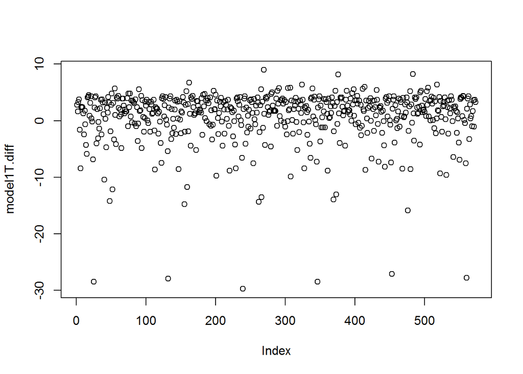

```r
plot(model1T.diff)
```

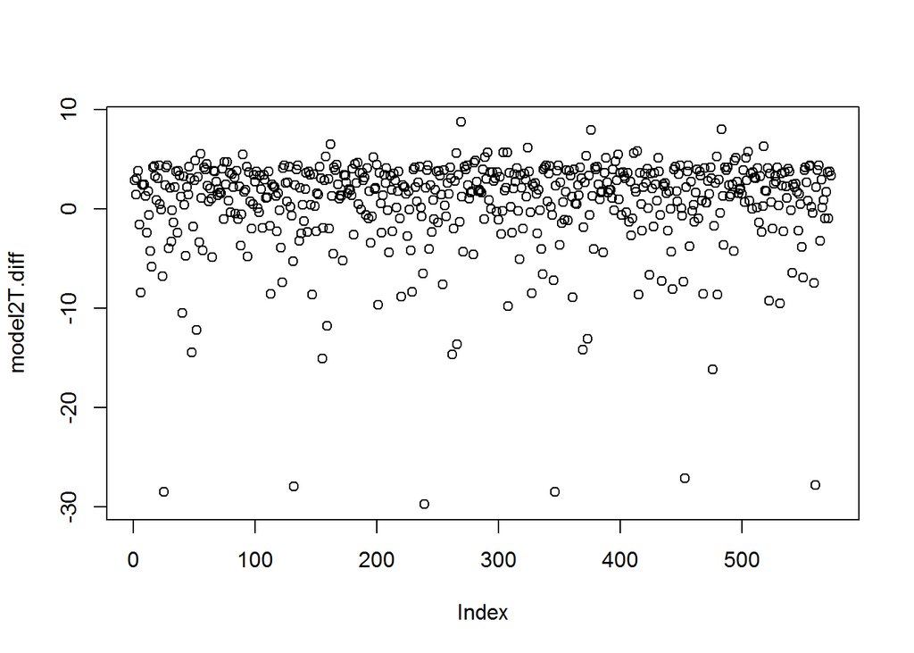

```r
plot(model2T.diff)
```

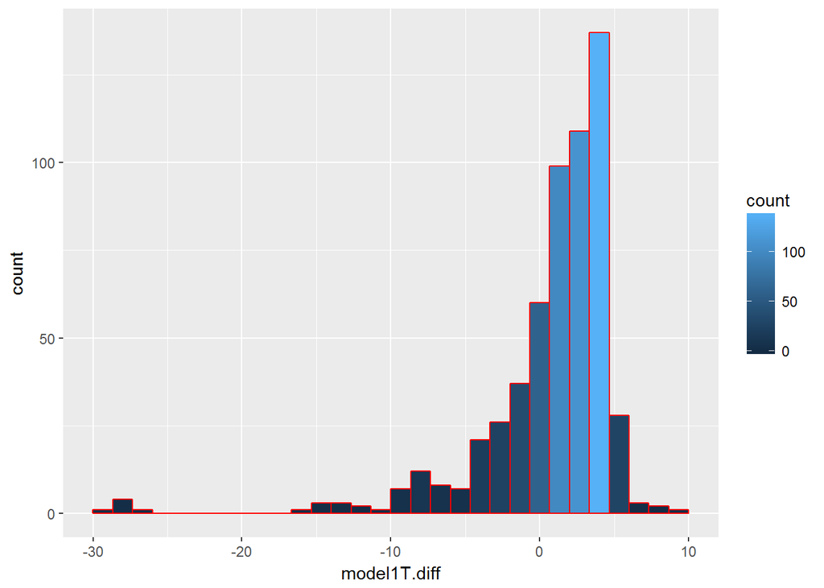

```r
ggplot(data=data.frame(model1T.diff), aes(model1T.diff)) +
  geom_histogram(col='red', aes(fill=..count..))
```

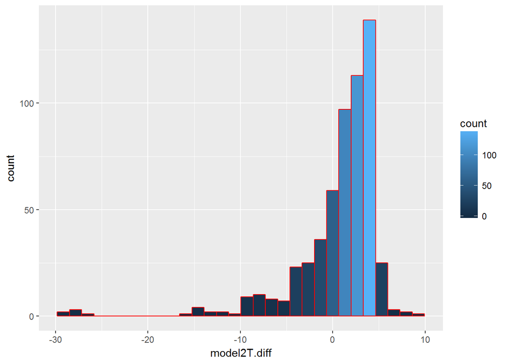

```r
ggplot(data=data.frame(model2T.diff), aes(model2T.diff)) +
  geom_histogram(col='red', aes(fill=..count..))
```

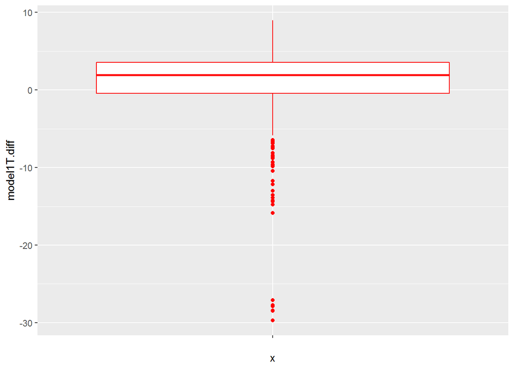

```r
ggplot(data = data.frame(model1T.diff), aes(x="", y=model1T.diff)) +
  geom_boxplot(col="red")
```

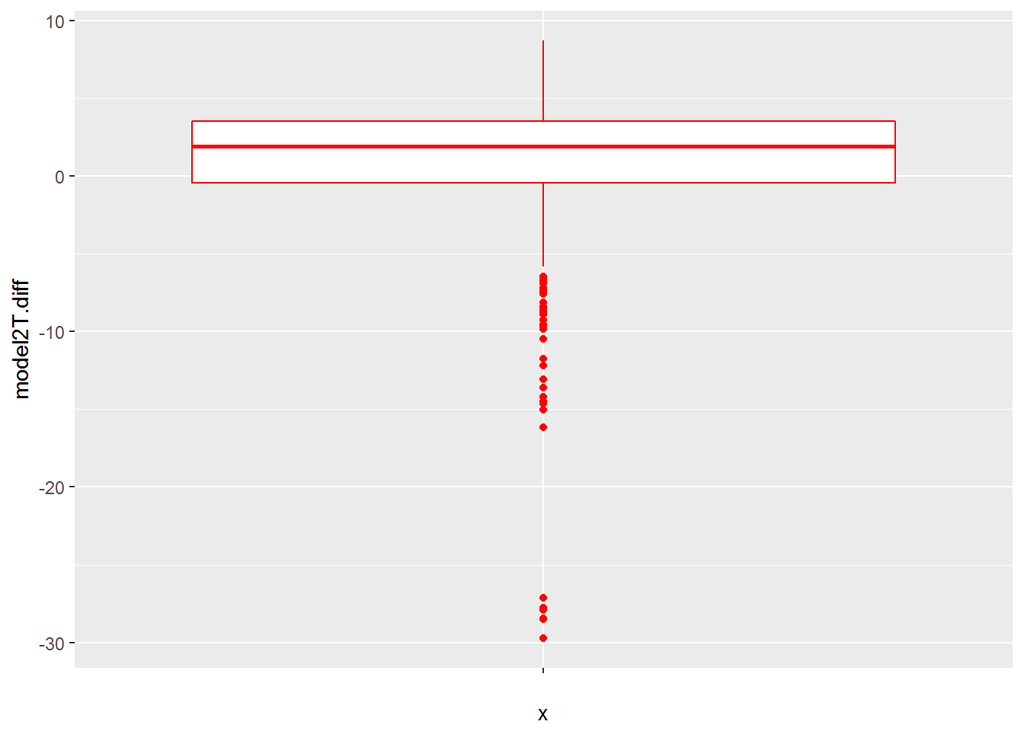

```r
ggplot(data = data.frame(model2T.diff), aes(x="", y=model2T.diff)) +
  geom_boxplot(col="red")
```

We see that we have a lot of outliers, but really 6 extreme outliers which are all from the same country. This country happens to be Trinidad and Tobago (TTO). What happens to our model when we remove them?

```r
newtotalScaled_TTO <- newtotalScaled[newtotalScaled$country!='TTO',]
```

```r
head(newtotalScaled_TTO)
```

```
##    year country alt_energy_per_tot        co2         gdp gdp_per_capita
## 4  1992     ALB          0.8415510  0.7747249 -0.29786814     -0.7074909
## 6  1992     ARE         -0.6788782 28.7945591 -0.25826535      1.0382666
## 7  1992     ARG         -0.1554426  3.6085822 -0.12912851     -0.2764167
## 8  1992     ARM         -0.2071464  1.5998956 -0.29745152     -0.6976355
## 11 1992     AUS         -0.5587524 15.3177685 -0.05776175      0.4962430
## 12 1992     AUT          0.2073218  7.2262364 -0.15441657      0.9043516
##    gdp_per_capita_growth        pop    pop_den  pop_growth group
## 4             -1.8410881 -0.3057691 -0.1388661 -1.48944732   ROW
## 6             -0.8866520 -0.3132379 -0.2486930  2.90977838   ROW
## 7              1.7229997 -0.1208282 -0.2624899 -0.03064161   G20
## 8             -8.9749161 -0.3045378 -0.1357728 -2.36103220   ROW
## 11            -0.6231689 -0.2191136 -0.2741536 -0.15295194   G20
## 12            -0.2492479 -0.2778306 -0.1662875 -0.23582149   ROW
```

We repeat our process with the training and testing data sets.

```r
#Have to create training data
newtotal_trainT_TTO <- newtotalScaled_TTO[1:1760, ]
newtotal_co2T_TTO <- newtotalScaled_TTO[1761:2332, 4]
test_co2T_TTO <- newtotalScaled_TTO[1761:2332,-4]
```

```r
head(newtotal_trainT_TTO)
```

```
##    year country alt_energy_per_tot        co2         gdp gdp_per_capita
## 4  1992     ALB          0.8415510  0.7747249 -0.29786814     -0.7074909
## 6  1992     ARE         -0.6788782 28.7945591 -0.25826535      1.0382666
## 7  1992     ARG         -0.1554426  3.6085822 -0.12912851     -0.2764167
## 8  1992     ARM         -0.2071464  1.5998956 -0.29745152     -0.6976355
## 11 1992     AUS         -0.5587524 15.3177685 -0.05776175      0.4962430
## 12 1992     AUT          0.2073218  7.2262364 -0.15441657      0.9043516
##    gdp_per_capita_growth        pop    pop_den  pop_growth group
## 4             -1.8410881 -0.3057691 -0.1388661 -1.48944732   ROW
## 6             -0.8866520 -0.3132379 -0.2486930  2.90977838   ROW
## 7              1.7229997 -0.1208282 -0.2624899 -0.03064161   G20
## 8             -8.9749161 -0.3045378 -0.1357728 -2.36103220   ROW
## 11            -0.6231689 -0.2191136 -0.2741536 -0.15295194   G20
## 12            -0.2492479 -0.2778306 -0.1662875 -0.23582149   ROW
```

```r
model1T_TTO <- plm(co2~alt_energy_per_tot+gdp+gdp_per_capita+pop+pop_den+pop_growth+group, data = newtotal_trainT_TTO, index=c("country", "year"), model="random", effect="time")
model2T_TTO <- plm(co2~alt_energy_per_tot+gdp+gdp_per_capita+pop+pop_growth+group, data = newtotal_trainT_TTO, index=c("country", "year"), model="random", effect="time")
```

```r
summary(model1T_TTO)
```

```
## Oneway (time) effect Random Effect Model
##    (Swamy-Arora's transformation)
##
## Call:
## plm(formula = co2 ~ alt_energy_per_tot + gdp + gdp_per_capita +
##     pop + pop_den + pop_growth + group, data = newtotal_trainT_TTO,
##     effect = "time", model = "random", index = c("country", "year"))
##
## Unbalanced Panel: n=106, T=16-17, N=1760
##
## Effects:
```

```
##                   var std.dev  share
## idiosyncratic 15.6160  3.9517  1.009
## time          -0.1427      NA -0.009
## theta  :
##    Min. 1st Qu.  Median    Mean 3rd Qu.    Max.
## -4.6330 -4.6330 -4.6330 -4.4850 -4.6330 -0.5518
##
## Residuals :
##     Min.  1st Qu.   Median     Mean  3rd Qu.     Max.
## -10.0000  -3.0300  -1.0800  -0.0343   2.0500  27.9000
##
## Coefficients :
##                     Estimate Std. Error t-value  Pr(>|t|)
## (Intercept)         7.907133   0.261422 30.2466 < 2.2e-16 ***
## alt_energy_per_tot -0.889441   0.118549 -7.5027 9.885e-14 ***
## gdp                 0.706089   0.147282  4.7941 1.772e-06 ***
## gdp_per_capita      2.072350   0.113967 18.1838 < 2.2e-16 ***
## pop                -0.981234   0.121828 -8.0542 1.463e-15 ***
## pop_den             0.157041   0.114469  1.3719    0.1703
## pop_growth          0.490817   0.098969  4.9593 7.760e-07 ***
## groupROW           -3.095209   0.316341 -9.7844 < 2.2e-16 ***
## ---
## Signif. codes:  0 '***' 0.001 '**' 0.01 '*' 0.05 '.' 0.1 ' ' 1
##
## Total Sum of Squares:    75414
## Residual Sum of Squares: 34622
## R-Squared:      0.54193
## Adj. R-Squared: 0.5401
## F-statistic: 294.89 on 7 and 1752 DF, p-value: < 2.22e-16
```

```r
summary(model2T_TTO)
```

```
## Oneway (time) effect Random Effect Model
##    (Swamy-Arora's transformation)
##
## Call:
## plm(formula = co2 ~ alt_energy_per_tot + gdp + gdp_per_capita +
##     pop + pop_growth + group, data = newtotal_trainT_TTO, effect = "time",
##     model = "random", index = c("country", "year"))
##
## Unbalanced Panel: n=106, T=16-17, N=1760
##
## Effects:
```

```
##                   var std.dev  share
## idiosyncratic 15.6224  3.9525  1.009
## time          -0.1431      NA -0.009
## theta  :
##    Min. 1st Qu.  Median    Mean 3rd Qu.    Max.
## -4.8950 -4.8950 -4.8950 -4.7370 -4.8950 -0.5549
##
## Residuals :
##    Min. 1st Qu.  Median    Mean 3rd Qu.    Max.
## -8.8300 -3.0400 -1.0600 -0.0336  2.0200 28.0000
##
## Coefficients :
##                    Estimate Std. Error t-value  Pr(>|t|)
## (Intercept)         7.91312    0.26193 30.2114 < 2.2e-16 ***
## alt_energy_per_tot -0.90063    0.11716 -7.6871 2.490e-14 ***
## gdp                 0.69010    0.14731  4.6847 3.020e-06 ***
## gdp_per_capita      2.03264    0.10904 18.6407 < 2.2e-16 ***
## pop                -0.99040    0.12222 -8.1034 9.915e-16 ***
## pop_growth          0.48482    0.09841  4.9265 9.158e-07 ***
## groupROW           -3.11166    0.31683 -9.8212 < 2.2e-16 ***
## ---
## Signif. codes:  0 '***' 0.001 '**' 0.01 '*' 0.05 '.' 0.1 ' ' 1
##
## Total Sum of Squares:    78755
## Residual Sum of Squares: 34980
## R-Squared:      0.5568
## Adj. R-Squared: 0.55528
## F-statistic: 365.631 on 6 and 1753 DF, p-value: < 2.22e-16
```

```r
predict.model1T_TTO <- predict(model1T_TTO,test_co2T_TTO)
predict.model2T_TTO <- predict(model2T_TTO,test_co2T_TTO)
model1T.diff_TTO <- newtotal_co2T_TTO - predict.model1T_TTO
model2T.diff_TTO <- newtotal_co2T_TTO - predict.model2T_TTO
```

```r
head(test_co2T_TTO)
```

```
##      year country alt_energy_per_tot        gdp gdp_per_capita
## 3572 2008     MNG         -0.6788782 -0.2942328     -0.5817050
## 3574 2008     MOZ          0.3647228 -0.2898888     -0.6890547
## 3576 2008     MUS         -0.6247803 -0.2910019     -0.1956969
## 3578 2008     MYS         -0.6165824 -0.1276304     -0.1657858
## 3581 2008     NGA         -0.6465324 -0.1444607     -0.6315978
## 3582 2008     NIC          0.1453597 -0.2921108     -0.6223634
##      gdp_per_capita_growth        pop    pop_den   pop_growth group
## 3572             1.0884886 -0.3095240 -0.2748341 -0.006524264   ROW
## 3574             0.3672082 -0.1856636 -0.2427677  1.013266449   ROW
## 3576             0.5936521 -0.3179508  0.4365651 -0.778491703   ROW
## 3578            -0.1300124 -0.1601038 -0.1804494  0.227393307   ROW
## 3581             0.2750724  0.5935622 -0.0836748  0.907700744   ROW
## 3582            -0.1353750 -0.2914918 -0.2226914 -0.087391954   ROW
```

```r
compare_TTO <- data.frame(predict.model1T_TTO, model1T.diff_TTO, predict.model2T_TTO, model2T.diff_TTO, newtotal_co2T_TTO)
head(compare_TTO)
```

```
##   predict.model1T_TTO model1T.diff_TTO predict.model2T_TTO
## 1            4.259848        0.3182092            4.330820
## 2            3.496257       -3.3977044            3.547462
## 3            4.755050       -1.7250581            4.703023
## 4            5.167023        2.3348613            5.200526
## 5            3.826033       -3.1897743            3.852454
## 6            3.394780       -2.6042925            3.450241
##   model2T.diff_TTO newtotal_co2T_TTO
## 1        0.2472372        4.57805706
## 2       -3.4489088        0.09855269
## 3       -1.6730316        3.02999146
## 4        2.3013584        7.50188391
## 5       -3.2161949        0.63625918
## 6       -2.6597533        0.79048763
```

```r
MSE1_TTO <- mean((compare_TTO$predict.model1T_TTO-compare_TTO$newtotal_co2T_TTO)^2)
RMSE1_TTO <- sqrt(MSE1_TTO)
RMSE1_TTO
```

```
## [1] 3.837791
```

```r
MSE2_TTO <- mean((compare_TTO$predict.model2T_TTO-compare_TTO$newtotal_co2T_TTO)^2)
RMSE2_TTO <- sqrt(MSE2_TTO)
RMSE2_TTO
```

```
## [1] 3.826064
```

Now we see our RMSE dropped by a good amount. It is still not the best, but it is better. We can once again check what our residuals look like.

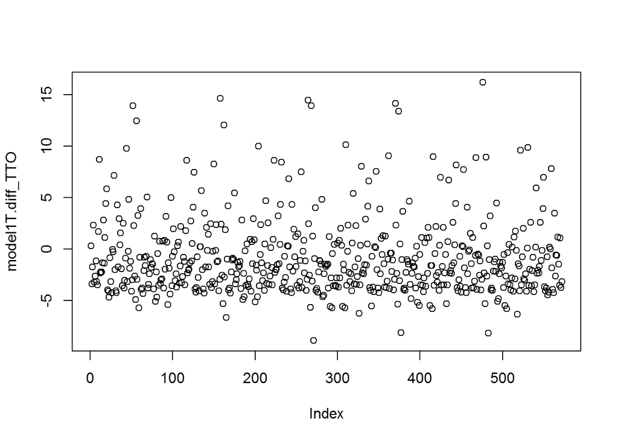

```r
plot(model1T.diff_TTO)
```

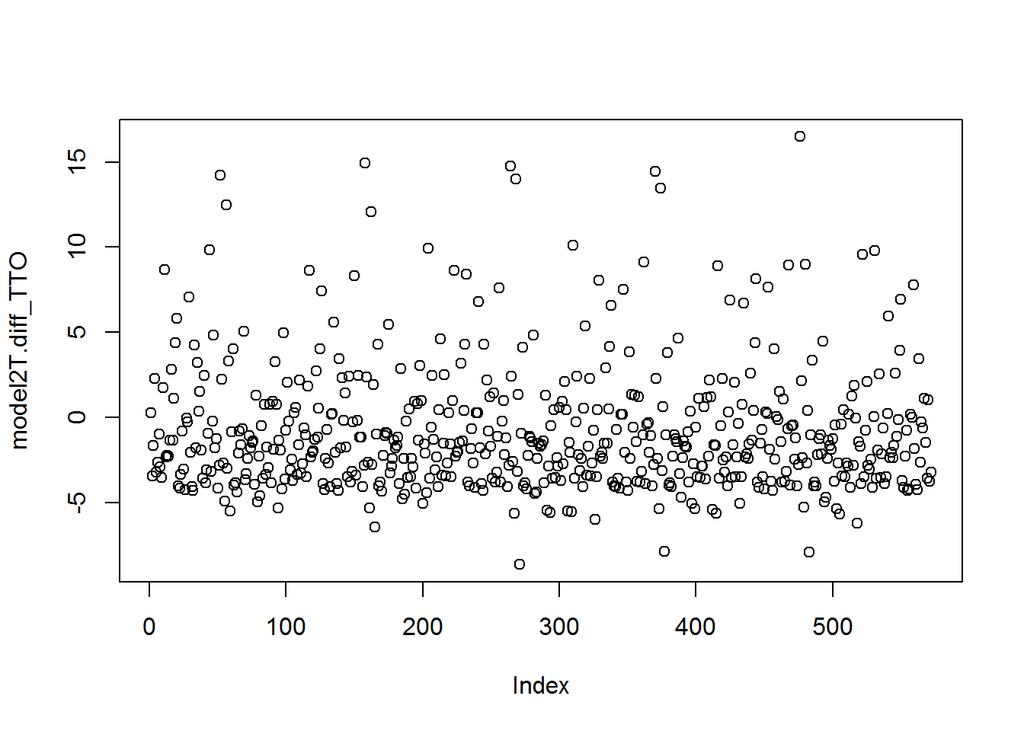

```r
plot(model2T.diff_TTO)
```

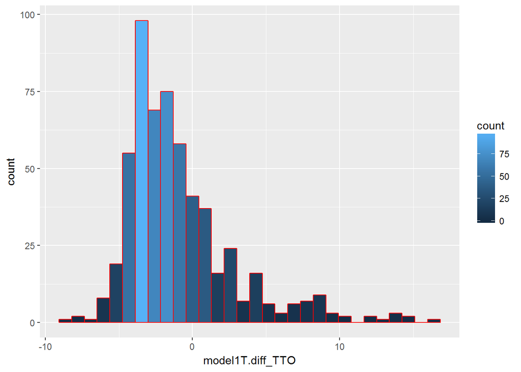

```r
ggplot(data=data.frame(model1T.diff_TTO), aes(model1T.diff_TTO)) +
  geom_histogram(col='red', aes(fill=..count..))
```

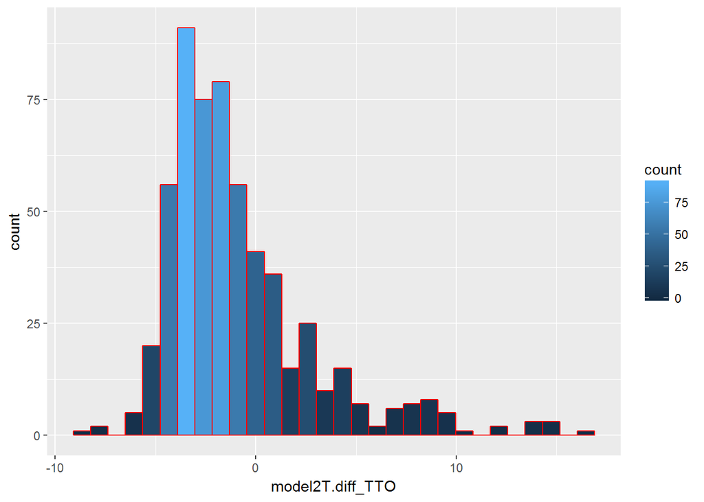

```r
ggplot(data=data.frame(model2T.diff_TTO), aes(model2T.diff_TTO)) +
  geom_histogram(col='red', aes(fill=..count..))
```

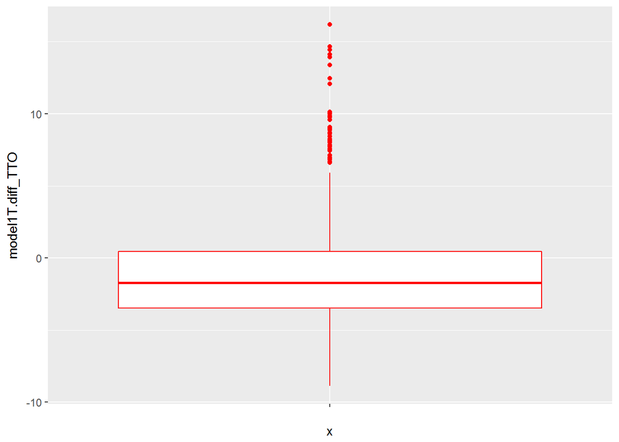

```r
ggplot(data = data.frame(model1T.diff_TTO), aes(x="", y=model1T.diff_TTO)) +
  geom_boxplot(col="red")
```

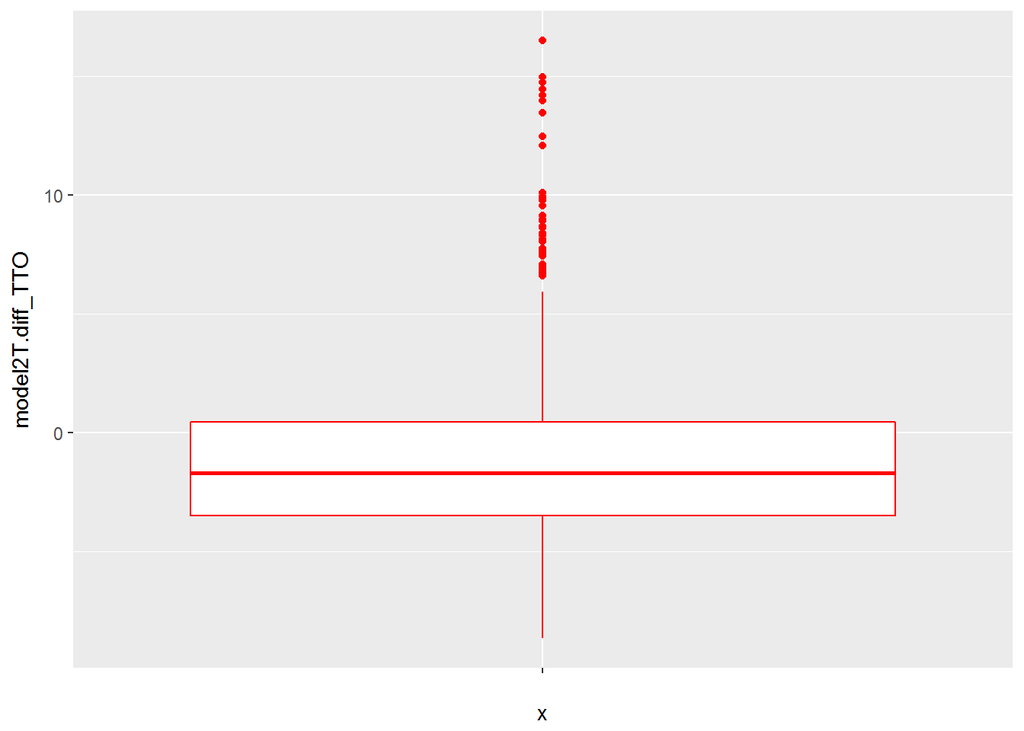

```r
ggplot(data = data.frame(model2T.diff_TTO), aes(x="", y=model2T.diff_TTO)) +
  geom_boxplot(col='red')
```

We then want to visualize our residuals. We do this by plotting the residuals versus the different variables. We do this using the variables actual values instead of the scaled values.

```r
d <- newtotal
d_TTO <- d[d$country!='TTO',]
d_TTO <- d_TTO[1761:2332,]
d_TTO$predicted <- predict.model2T_TTO
d_TTO$residuals <- model2T.diff_TTO
head(d_TTO)
```

```
##      year country alt_energy_per_tot        co2          gdp gdp_growth
## 3572 2008     MNG          0.0000000 4.57805706   5623216449   8.900368
## 3574 2008     MOZ         14.0206970 0.09855269  11494837053   6.876205
## 3576 2008     MUS          0.7268009 3.02999146   9990370016   5.386963
## 3578 2008     MYS          0.8369389 7.50188391 230814000000   3.319594
## 3581 2008     NGA          0.4345629 0.63625918 208065000000   6.270264
## 3582 2008     NIC         11.0735710 0.79048763   8491388729   2.851711
##      gdp_per_capita gdp_per_capita_growth       pop    pop_den pop_growth
## 3572      2138.3767              7.372670   2629666   1.692671  1.4127726
## 3574       499.8871              3.923765  22994867  29.241419  2.8013603
## 3576      8030.0630              5.006539   1244121 612.867488  0.3616308
## 3578      8486.5993              1.546234  27197419  82.780152  1.7312841
## 3581      1376.8574              3.483205 151115683 165.920796  2.6576178
## 3582      1517.8036              1.520592   5594524  46.489314  1.3026599
##      urb_pop_growth urb_pop_per group predicted  residuals
## 3572      2.9756553      65.581   ROW  4.330820  0.2472372
## 3574      3.4055155      30.548   ROW  3.547462 -3.4489088
## 3576     -0.1445936      40.995   ROW  4.703023 -1.6730316
## 3578      2.9887032      69.225   ROW  5.200526  2.3013584
## 3581      4.7977603      41.702   ROW  3.852454 -3.2161949
## 3582      1.7693554      56.701   ROW  3.450241 -2.6597533
```

The plots below represent the residuals by showing the variables vs co2, plotting both the actual values and our predicted values connected. The colored points are the actual values while the white dots are our predicted values. Red shows that we under predicted while the blue shows an over prediction.

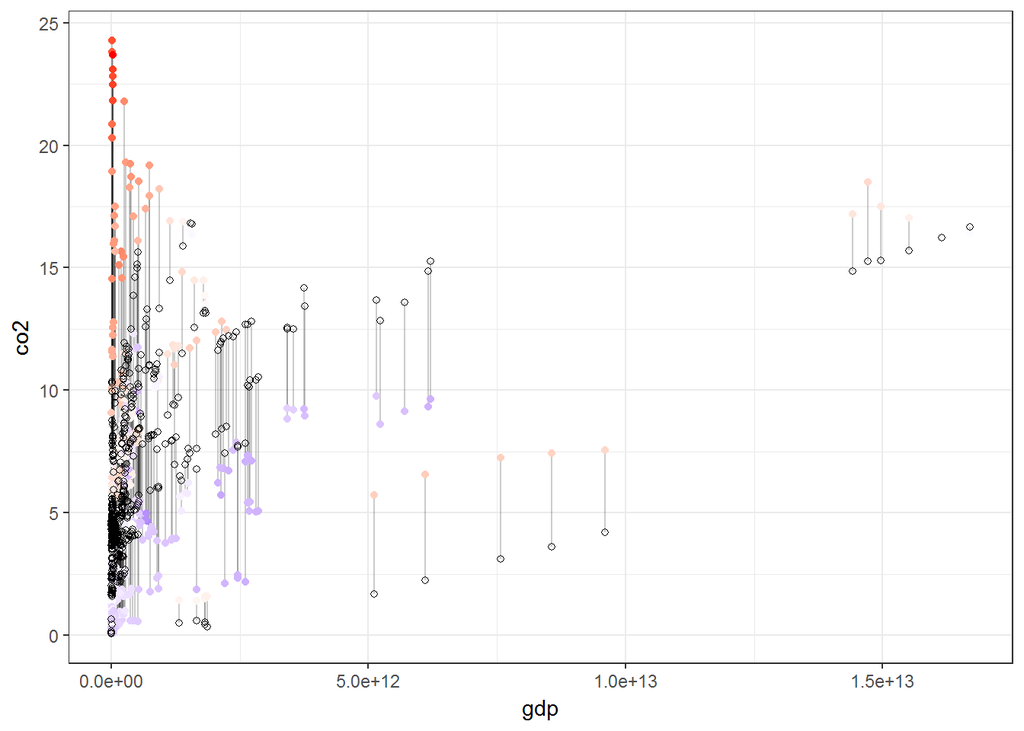

```r
ggplot(d_TTO, aes(x=gdp, y=co2)) +
  geom_segment(aes(xend=gdp, yend=predicted), alpha=.2) +
  geom_point(aes(color=residuals)) +
  scale_color_gradient2(low="blue", mid="white", high="red") +
  guides(color=FALSE) +
  geom_point(aes(y=predicted), shape=1) +
  theme_bw()
```

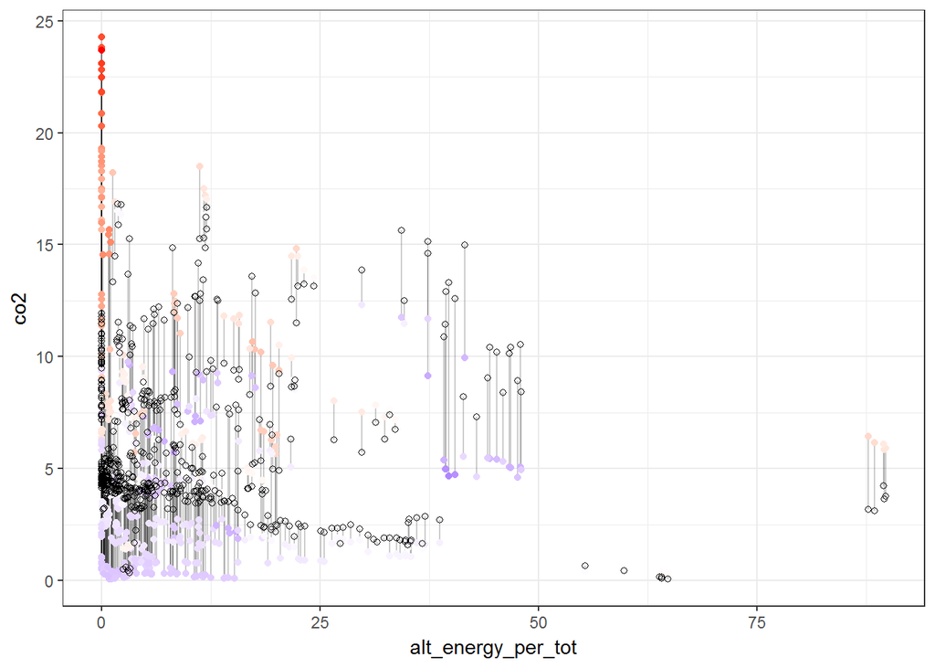

```r
ggplot(d_TTO, aes(x=alt_energy_per_tot, y=co2)) +
  geom_segment(aes(xend=alt_energy_per_tot, yend=predicted), alpha=.2) +
  geom_point(aes(color=residuals)) +
  scale_color_gradient2(low="blue", mid="white", high="red") +
  guides(color=FALSE) +
  geom_point(aes(y=predicted), shape=1) +
  theme_bw()
```